# Multi-class Classification

Yuan Huang

### Introduction

This project implemented the one-vs-all logistic regression and the feedforward propagation of neutral networks using R. This markdown file read the data files and organized functions defined in the function list. The corresponding notebook and the markdown files also explained the derivation of the basic equations used for the implementation of the algorithms. The data used in this project are ex3data1X.txt, ex3dataY.txt, ex3dataTheta1.txt and ex3dataTheta2.txt. These txt files are included in the folder.

#### Function list: Functions implemented in this markdown notebook

- sigmoid - Sigmoid Function
- predictOneVsAll - One-vs-all Logistic Regression Prediction Function
- fR - Regularized Logistic Regression cost function
- gR - Regularized Logistic Regression gradient function
- predict - Neural network prediction function

Before we implement the functions, we first load the R libraries for this project.

`r`r #load the library library(ggplot2) library(Rcgmin)

**1. Multi-class Classification**  
In this section, we will use logistic regression and neural networks to recognize handwritten digits (from 0 to 9). Example images of these digits are shown below:

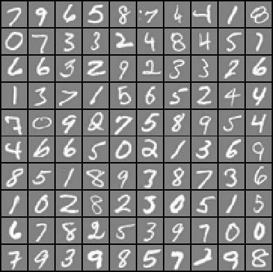

sample digit images

**1.1 Dataset**  
The data set in ex3data1X.txt and ex3dataY.txt contains 5000 training examples of handwritten digits. Now let’s first read the data.

`r`r cat(dimension of targety is ,dim(targety),\n)

```
The dimension of targety is  5000 1
```

In the dataset, each training exmple is a 20 pixel by 20 pixel grayscale image of the digit. Each pixel is represented by a floating point number indicating the grayscale intensity at that location. The 20 by 20 grid of pixels have been converted to a 400-dimensional vector in the input file of ex3data1X.txt.

The task of this project is to correctly predict the number given the image vector of that number in the training set. We will first try the one-vs-all logistic regression model. To build the logistic regression model, we first build the design matrix by adding the intercept column to the image_X dataframe.

`r`r number_labels<-10 feature_number<-dim(image_X)[2]+1 design_matrix<-as.matrix(cbind(v0=rep(1,times=dim(image_X)[1]),image_X))

**1.2 Vectorizing Logistic Regression**  
In the one-vs-all logistic regression model, we will need to train multiple logistic regression classifiers. Vectorizing the code is important to make sure the training is effiecient.

Vectorized logistic regression algorithm and equations for computing cost and gradient for regularized logistic regression have been dervied in the logistic regression project. Please refer to LogisticRegression.nb.html markdown notebook for the details of the derivation. In this project, I just listed the equations for regularized logistic regression as follows:

$$J \left( \theta \right) = -\frac{1}{m} \left[ Y^Tlog\left(sigmoid \left(X \theta \right)\right) +(1-Y)^Tlog(1-sigmoid(X\theta)) \right]+ \frac{\lambda}{2m}\theta_{\left[1:n\right]}^T\theta_{\left[1:n\right]} ~~~~~~~~~~~Eq(1)$$

`r`r sigmoid<-function(x) 1/(exp(-x)+1) fR<-function(theta,X,y,lambda){ m<-length(y) cost<- -1*(1/m)*(t(y)%*%log(sigmoid(X%*%theta))+t(1-y)%*%log(1-sigmoid(X%*%theta)))+ lambda/(2*m)*t(theta[-1])%*%theta[-1] return(cost[1,1]) } gR<-function(theta,X,y,lambda){ m<-length(y) grad<–(1/m)*(t(y-sigmoid(X%*%theta))%*%X) grad[-1]<- grad[-1]+lambda/m*theta[-1] return(t(grad)) }

**1.3. One-vs-all Classification**  
In this part of the project, we implemented one-vs-all classfication algorithm by tarining multiple regularized losgistic regression classifiers, one for each class. Each classifier predicted the probability of an observation belonging to a particular class. We then assigned the observation to the class having the highest probability.

In the following implementation, a matrix called thetas were created. This matrix contains 10 rows and 401 columns. Each row of the thetas contains the learned logistic regression parameters for one class.

`r`r thetas<-matrix(rep(0,times=number_labels*feature_number),nrow=number_labels)

Next, we will train the multi-class model by training multiple classifiers. This was done by a for loop. When index i changed from 1 to 10, the 10 classifiers were trained sequentially, and the learned theta values for each classifier were stored in the corresponding row of thetas matrix.

Furthermore, Rcgmin function in Rcgmin package was used to find the optimum theta corresponding to the minimum cost. This function uses the conjugated gradient minimization algorithm for the efficient search of the optimum values. In the following R code, we used an initial theta vector with all its elements setting at 0 for all the classifiers.

Finally, it is important to note that each classifier acts as a “binary” classifer. For example, classifier i only cares if an observation belongs to class i or not. Therefore, when training classifier i, we only need to tell the classifier whether an observation belongs to class i, as shown in the following code.

`r`r initial_theta<-rep(0,times=feature_number) for (i in seq(number_labels)){ thetas[i,]<-Rcgmin(par=initial_theta,fR,gR,X=design_matrix,y=as.integer(targety==i),lambda=0.1)$par }

`r`r predictAllVsOne<-function(model_X,thetas){ predict<-sigmoid(model_X%*%t(thetas)) results<-apply(predict,1,function(x) which(x==max(x),arr.ind=TRUE)) } pred_results<-predictAllVsOne(design_matrix,thetas) mean(pred_results==targety)*100

```
[1] 96.46
```

The accuracy of the multi-class logistic regression model is ~ 96% for the digit number recognition.

**2. Neural Networks**  
This part of the project implemented a neural network to recognize handwritten digits using the same training dataset as before. For this project, network weight parameters from a neural network that had been trained were used to predict which digit numbers the images contained for training examples. The goal is to implement the feedforward propagation algorithm to use the weights obtained from a trained neural network model for prediction. In the next project, the backpropagation algorithm for learning the neural network parameters will be implemented.

If you understand the logistic regression, then the feedforwad propagation is just a combination of multiple logistic regression models. Let’s start from a simple case where there are four input nodes and one output node, as shown in the following figure:

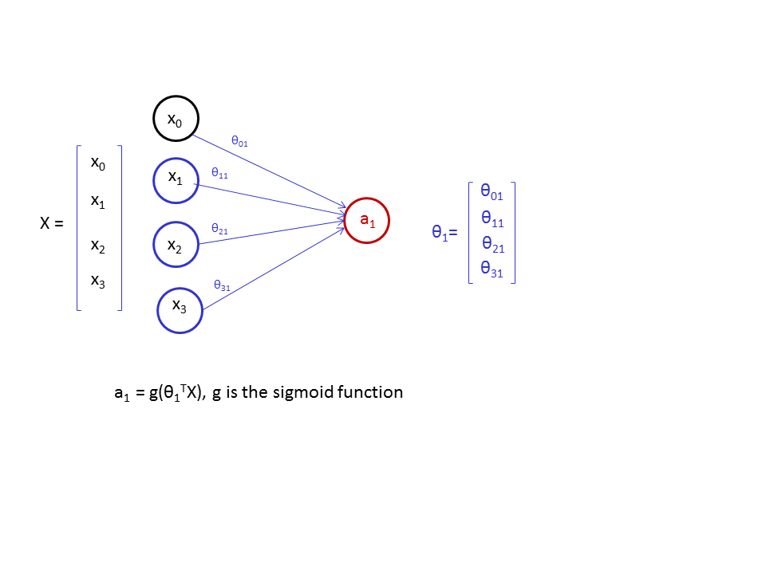

In this figure, the output node, $a_1=g(\theta_1^TX)$ where g is the sigmoid function. Now if we add another output node, $a_2$, then $a_2=g(\theta_2^TX)$. Finally, if we combine the two output nodes $a_1$ and $a_2$ into a vector, a, then the vector can be computed as $a=g(\theta X)$, where $\theta$ is a matrix consisting of $\theta_1^T$ and $\theta_2^T$ as its two rows. The two output node case is shown in the following figure:

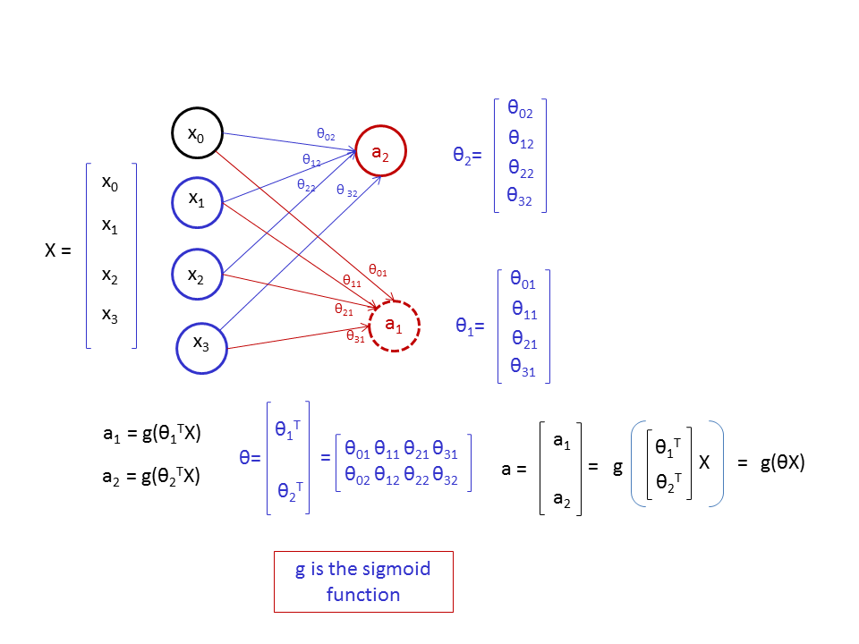

According to this discussion, dimension of the parameter matrix $\theta$ should be consistent to the numbers of nodes in the adjacent layers involved in the transformation. The number of rows of $\theta$ matrix equals the number of output nodes (excluding the bias node) of the transformation, while the number of the columns of $\theta$ matrix equals the number of input nodes including the bias node of the tranformation.

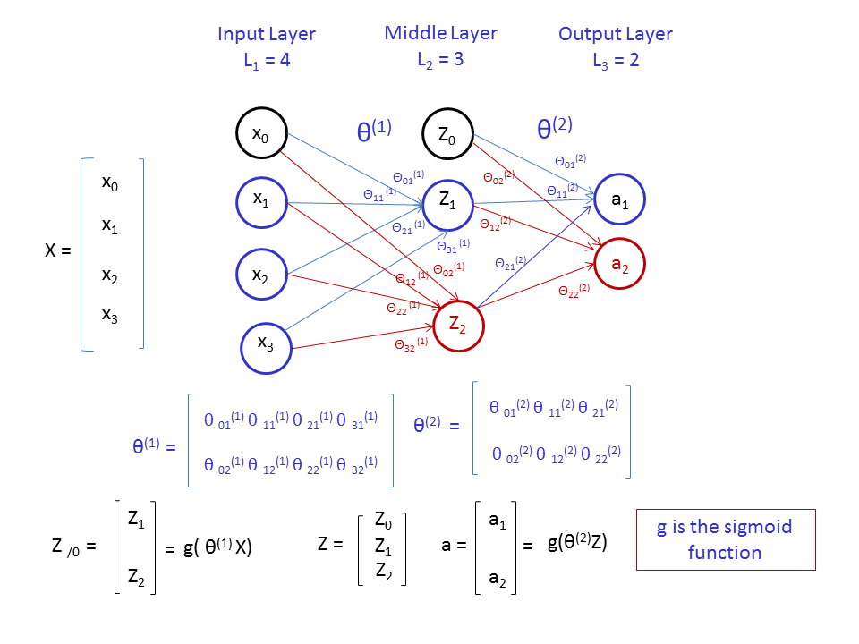

The neural network used in this project is a 3 layer network, including an input layer, a middle layer and an output layer. The same input data used in the previous multi-class logistic regression model was used in this section. The input layer of the neural network including the bias node has 401 nodes. The middle layer was designed to have 25 nodes, and the output layer has 10 nodes, corresponding to the 10 different output classes.

Now, let’s read the theta1 and theta2 data, which were obtained by training the neural network.

```
The dimension of theta2 is:  10 26
```

As shown in the previous figure, feedforward algorithm calculates the value of every node except those in the input layer using the nodes in the previous layer and the corresponding parameter matrix. For example, nodes in the third layer (output layer) are computed based on middle layer nodes and the parameter matrix $\theta^{(2)}$. Nodes in the middle layer are computed using nodes in the input layer and the parameter matrix $\theta^{(1)}$.

```
the accuracy by neron net work is  97.52
```